# Credit Risk

Daniel Garcia

2023-04-15

#### libraries

```r
library(tidyverse)
library(tree)
library(skimr)
library(MASS)
library(ROCR)
library(randomForest)
library(gbm)
```

#### Data

```r
# importing data
credit = read_csv("C:\\Users\\dgray\\OneDrive\\Stats\\Stat 473 Machine learning\\Data\\german_credit_data.csv")
```

```
## ──────────────────────────────────────────────────────── Delimiter: "," chr
## (6): Sex, Housing, Saving accounts, Checking account, Purpose, Risk dbl (5):
## ...1, Age, Job, Credit amount, Duration
```

```r
# observing data
glimpse(credit)
```

```
## Rows: 1,000
## Columns: 11
## $ ...1               <dbl> 0, 1, 2, 3, 4, 5, 6, 7, 8, 9, 10, 11, 12, 13, 14, 1…
## $ Age                <dbl> 67, 22, 49, 45, 53, 35, 53, 35, 61, 28, 25, 24, 22,…
## $ Sex                <chr> "male", "female", "male", "male", "male", "male", "…
## $ Job                <dbl> 2, 2, 1, 2, 2, 1, 2, 3, 1, 3, 2, 2, 2, 1, 2, 1, 2, …
## $ Housing            <chr> "own", "own", "own", "free", "free", "free", "own",…
## $ `Saving accounts`  <chr> NA, "little", "little", "little", "little", NA, "qu…
## $ `Checking account` <chr> "little", "moderate", NA, "little", "little", NA, N…
## $ `Credit amount`    <dbl> 1169, 5951, 2096, 7882, 4870, 9055, 2835, 6948, 305…
## $ Duration           <dbl> 6, 48, 12, 42, 24, 36, 24, 36, 12, 30, 12, 48, 12, …
## $ Purpose            <chr> "radio/TV", "radio/TV", "education", "furniture/equ…
## $ Risk               <chr> "good", "bad", "good", "good", "bad", "good", "good…
```

```r
unique(credit$`Saving accounts`)
```

```
## [1] NA           "little"     "quite rich" "rich"       "moderate"
```

```r
unique(credit$`Checking account`)
```

```
## [1] "little"   "moderate" NA         "rich"
```

#### cleaning data

```r
colnames(credit)[c(1, 6, 7, 8)]= c("id", "Saving_accounts", "Checking_accounts", "Credit_amount")
glimpse(credit)
```

```
## Rows: 1,000
## Columns: 11
## $ id                <dbl> 0, 1, 2, 3, 4, 5, 6, 7, 8, 9, 10, 11, 12, 13, 14, 15…
## $ Age               <dbl> 67, 22, 49, 45, 53, 35, 53, 35, 61, 28, 25, 24, 22, …
## $ Sex               <chr> "male", "female", "male", "male", "male", "male", "m…
## $ Job               <dbl> 2, 2, 1, 2, 2, 1, 2, 3, 1, 3, 2, 2, 2, 1, 2, 1, 2, 2…
## $ Housing           <chr> "own", "own", "own", "free", "free", "free", "own", …
## $ Saving_accounts   <chr> NA, "little", "little", "little", "little", NA, "qui…
## $ Checking_accounts <chr> "little", "moderate", NA, "little", "little", NA, NA…
## $ Credit_amount     <dbl> 1169, 5951, 2096, 7882, 4870, 9055, 2835, 6948, 3059…
## $ Duration          <dbl> 6, 48, 12, 42, 24, 36, 24, 36, 12, 30, 12, 48, 12, 2…
## $ Purpose           <chr> "radio/TV", "radio/TV", "education", "furniture/equi…
## $ Risk              <chr> "good", "bad", "good", "good", "bad", "good", "good"…
```

```r
# checking for NA values
na.credit = credit[rowSums(is.na(credit))>0,]
na.credit
```

```
## # A tibble: 478 × 11
##       id   Age Sex     Job Housing Saving_accounts Checking_accounts
##    <dbl> <dbl> <chr> <dbl> <chr>   <chr>           <chr>
##  1     0    67 male      2 own     <NA>            little
##  2     2    49 male      1 own     little          <NA>
##  3     5    35 male      1 free    <NA>            <NA>
##  4     6    53 male      2 own     quite rich      <NA>
##  5     8    61 male      1 own     rich            <NA>
##  6    16    53 male      2 own     <NA>            <NA>
##  7    17    25 male      2 own     <NA>            little
##  8    19    31 male      2 own     quite rich      <NA>
##  9    20    48 male      2 own     little          <NA>
## 10    24    26 male      2 own     <NA>            <NA>
## # ℹ 468 more rows
## # ℹ 4 more variables: Credit_amount <dbl>, Duration <dbl>, Purpose <chr>,
## #   Risk <chr>
```

```r
sum(is.na(credit$Checking_accounts))
```

```
## [1] 394
```

```r
sum(is.na(credit$Saving_accounts))
```

```
## [1] 183
```

```r
unique(credit$Checking_accounts)
```

```
## [1] "little"   "moderate" NA         "rich"
```

478 observations have NA values in at least 1 column. Without going through all observations, only savings accounts and checkings accounts columns are the only columns that produce NA’s.

- number of NA values in Saving_accounts column: 183
- number of NA values in Checking_accounts column: 394
- unique values in Saving accounts: NA, little, quite rich, rich, moderate.
- unique values in Saving accounts: NA, little, rich, moderate.

**lets replace all NA values with “none”**

```r
# replace NA values with "none"
credit[is.na(credit)]="none"
glimpse(credit)
```

```
## Rows: 1,000
## Columns: 11
## $ id                <dbl> 0, 1, 2, 3, 4, 5, 6, 7, 8, 9, 10, 11, 12, 13, 14, 15…
## $ Age               <dbl> 67, 22, 49, 45, 53, 35, 53, 35, 61, 28, 25, 24, 22, …
## $ Sex               <chr> "male", "female", "male", "male", "male", "male", "m…
## $ Job               <dbl> 2, 2, 1, 2, 2, 1, 2, 3, 1, 3, 2, 2, 2, 1, 2, 1, 2, 2…
## $ Housing           <chr> "own", "own", "own", "free", "free", "free", "own", …
## $ Saving_accounts   <chr> "none", "little", "little", "little", "little", "non…
## $ Checking_accounts <chr> "little", "moderate", "none", "little", "little", "n…
## $ Credit_amount     <dbl> 1169, 5951, 2096, 7882, 4870, 9055, 2835, 6948, 3059…
## $ Duration          <dbl> 6, 48, 12, 42, 24, 36, 24, 36, 12, 30, 12, 48, 12, 2…
## $ Purpose           <chr> "radio/TV", "radio/TV", "education", "furniture/equi…
## $ Risk              <chr> "good", "bad", "good", "good", "bad", "good", "good"…
```

```r
df7=credit %>%
  filter(Saving_accounts=="none" | Checking_accounts=="none")
nrow(df7)
```

```
## [1] 478
```

```r
df7 %>%
  filter(Risk=="good") %>%
  nrow()
```

```
## [1] 409
```

- 409/478 applicants who had NA values in Saving accounts or Checking accounts were identified as good risk clients

now that the data is clean, lets start Exploratory data analysis

```r
# create training set and testing set
n = nrow(credit)

set.seed(1)
Z = sample(n, size=n*0.8)

train_set = credit[Z,]
test_set=credit[-Z,]
```

#### EDA

```r
skim(credit)
```

Data summary

| Name | credit |
| --- | --- |
| Number of rows | 1000 |
| Number of columns | 11 |
| _______________________ |  |
| Column type frequency: |  |
| character | 6 |
| numeric | 5 |
| ________________________ |  |
| Group variables | None |

**Variable type: character**

| skim_variable | n_missing | complete_rate | min | max | empty | n_unique | whitespace |
| --- | --- | --- | --- | --- | --- | --- | --- |
| Sex | 0 | 1 | 4 | 6 | 0 | 2 | 0 |
| Housing | 0 | 1 | 3 | 4 | 0 | 3 | 0 |
| Saving_accounts | 0 | 1 | 4 | 10 | 0 | 5 | 0 |
| Checking_accounts | 0 | 1 | 4 | 8 | 0 | 4 | 0 |
| Purpose | 0 | 1 | 3 | 19 | 0 | 8 | 0 |
| Risk | 0 | 1 | 3 | 4 | 0 | 2 | 0 |

**Variable type: numeric**

| skim_variable | n_missing | complete_rate | mean | sd | p0 | p25 | p50 | p75 | p100 | hist |
| --- | --- | --- | --- | --- | --- | --- | --- | --- | --- | --- |
| id | 0 | 1 | 499.50 | 288.82 | 0 | 249.75 | 499.5 | 749.25 | 999 | ▇▇▇▇▇ |
| Age | 0 | 1 | 35.55 | 11.38 | 19 | 27.00 | 33.0 | 42.00 | 75 | ▇▆▃▁▁ |
| Job | 0 | 1 | 1.90 | 0.65 | 0 | 2.00 | 2.0 | 2.00 | 3 | ▁▂▁▇▂ |
| Credit_amount | 0 | 1 | 3271.26 | 2822.74 | 250 | 1365.50 | 2319.5 | 3972.25 | 18424 | ▇▂▁▁▁ |
| Duration | 0 | 1 | 20.90 | 12.06 | 4 | 12.00 | 18.0 | 24.00 | 72 | ▇▇▂▁▁ |

- mean age is about 36
- mean credit amount is about $3,270
- mean duration is about 21 months

```r
sum(credit$Risk=="bad")/nrow(credit)
```

```
## [1] 0.3
```

**30% of our data has credit risk classified as bad, 70% is good**

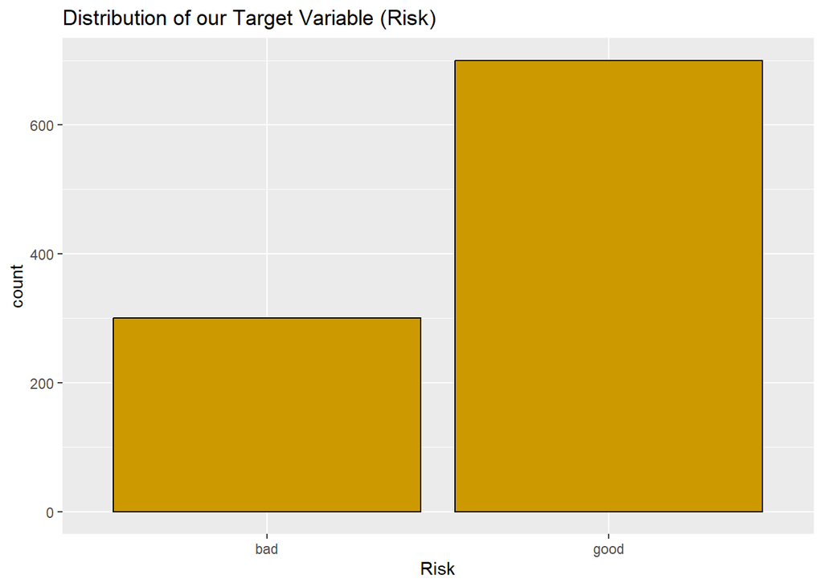

```r
ggplot(data=credit, mapping=aes(x=Risk)) +
  geom_bar(fill="#CC9900", color="black") +
  labs(title="Distribution of our Target Variable (Risk)")
```

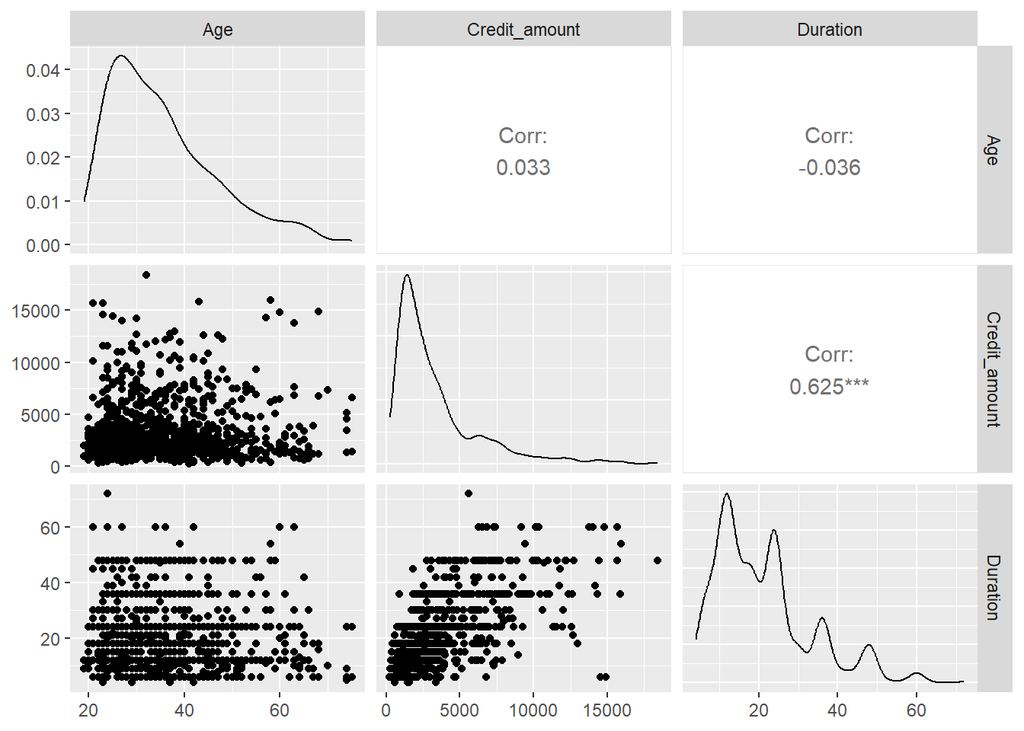

```r
numerical_credit = credit %>%
  dplyr::select(2, 8, 9)
GGally::ggpairs(numerical_credit)
```

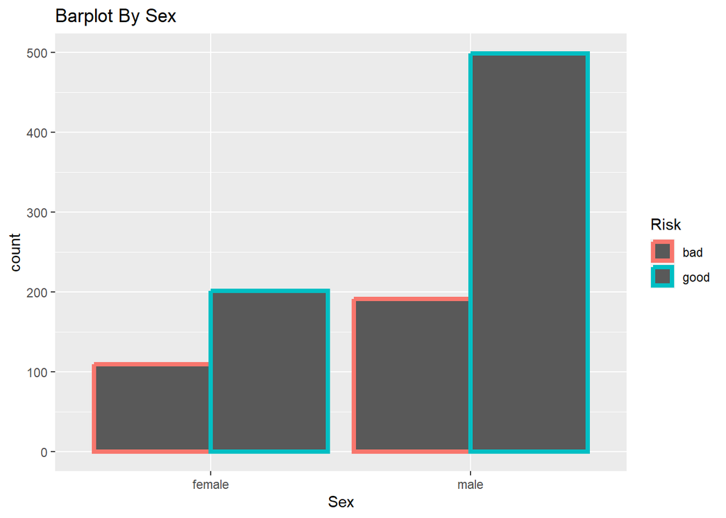

```r
ggplot(credit, aes(x=Sex, color=as.factor(Risk))) +
  geom_bar(size=1.5, position="dodge") +
  labs(title="Barplot By Sex", color="Risk")
```

- over 1/3 of loans to females result in bad loans.
- around 1/4 of all loans to males result in bad loans.

```r
credit %>%
  filter(Sex=="male" & Risk=="good") %>%
  nrow()
```

```
## [1] 499
```

```r
credit %>%
  filter(Sex=="male" & Risk=="bad") %>%
  nrow()
```

```
## [1] 191
```

```r
499/191
```

```
## [1] 2.612565
```